# Reproducible Research – Peer Assessments 1

## Loading and preprocessing the data

### 1. Load the data

Download the zipfile, unzip the downloaded file and load the data.

```r
fileUrl <- "http://d396qusza40orc.cloudfront.net/repdata%2Fdata%2Factivity.zip"
download.file(fileUrl, destfile = "data.zip")
unzip("data.zip")
data <- read.csv("activity.csv")
```

### 2. Process/transform the data into a format suitable for your analysis

Convert data type of “date” column into date type.

```r
data$date <- as.Date(data$date, "%Y-%m-%d")
```

## What is mean total number of steps taken per day?

### 1. Calculate the total number of steps taken per day

Calculate the sum of steps for each day.

```r
date_sum <- aggregate(data$steps, by=list(data$date), FUN = "sum")
colnames(date_sum) <- c("date", "steps")
```

### 2. Make a histogram of the total number of steps taken each day

Plot the histogram.

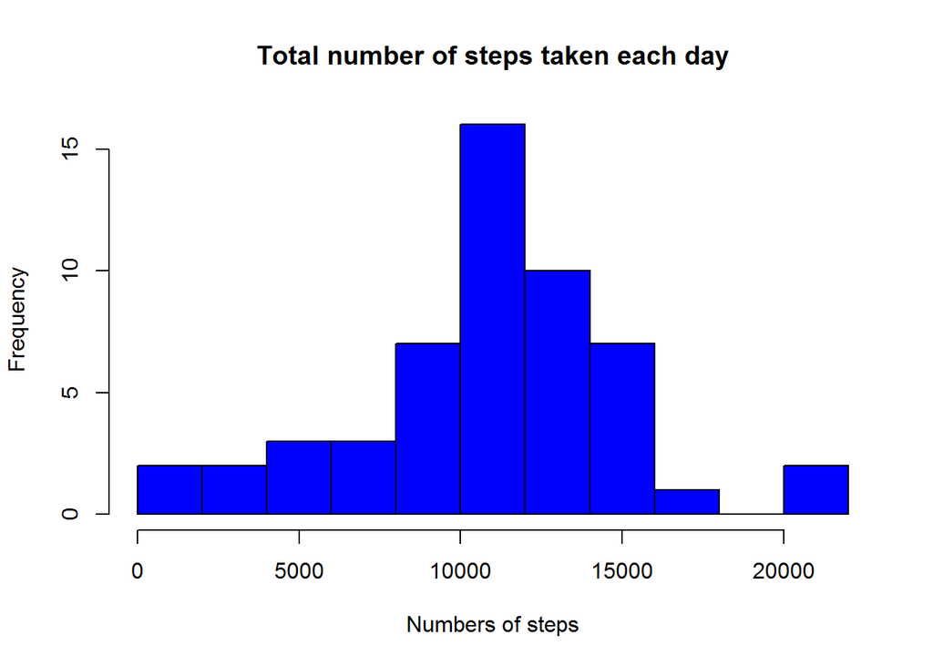

```r
hist(date_sum$steps, breaks = 15, col="blue", xlab = "Numbers of steps",
     main = "Total number of steps taken each day")
```

### 3. Calculate and report the mean and median of the total number of steps taken per day

```r
mean_steps <- mean(date_sum$steps, na.rm = TRUE)
median_steps <- median(date_sum$steps, na.rm = TRUE)
```

The mean of the total number of steps taken per day is 10766.2, and the median of the total number of steps taken per day is 10765.

## What is the average daily activity pattern?

### 1. Make a time series plot of the 5-minute interval (x-axis) and the average number of steps taken, averaged across all days (y-axis)

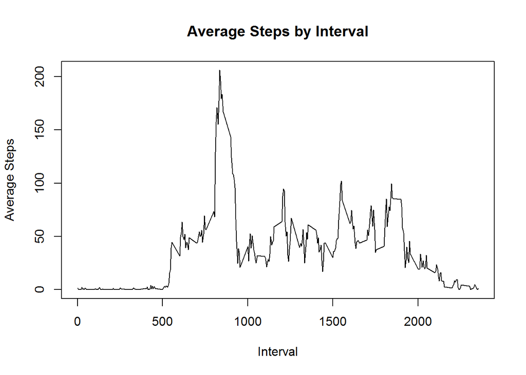

```r
interval_avg <- aggregate(data$steps, by=list(data$interval), FUN = mean,
                          na.rm = TRUE)
colnames(interval_avg) <- c("interval", "average_steps")
with(interval_avg, plot(interval, average_steps, type= "l",
     xlab = "Interval", ylab = "Average Steps",
     main = "Average Steps by Interval"))
```

### 2. Which 5-minute interval, on average across all the days in the dataset, contains the maximum number of steps?

```r
max_interval <- interval_avg[which.max(interval_avg[, 2]), 1]
```

The 5-minute interval which contains the maximum number of steps is 835.

## Imputing missing values

### 1. Calculate and report the total number of missing values in the dataset

```r
na_count <- sum(is.na(data[, 1]))
```

The total number of missing values in the dataset is 2304.

### 2. Devise a strategy for filling in all of the missing values in the dataset

Let’s use the mean for the 5-minute interval to populate NA values for a given interval.

```r
data2 <- data

for (i in 1:17568){
    if (is.na(data[i, 1])){
        data2[i, 1] <- interval_avg[interval_avg$interval == data[i, 3], 2]
    }
}
```

### 3. Make a histogram of the total number of steps taken each day

Calculate the sum of steps for each day with missing value-filled data, and make a histogram.

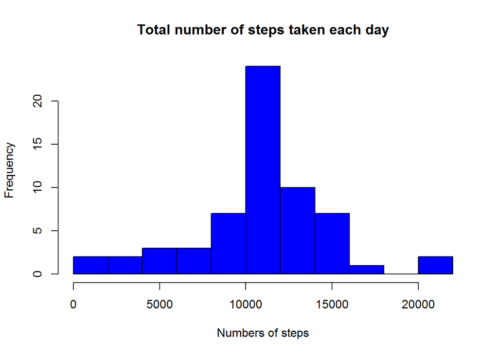

```r
date_sum2 <- aggregate(data2$steps, by = list(data2$date), FUN = "sum")
colnames(date_sum2) <- c("date", "steps")
hist(date_sum2$steps, breaks = 15, col="blue", xlab = "Numbers of steps",
     main = "Total number of steps taken each day")
```

### 4. Calculate and report the mean and median total number of steps taken per day.

```r
mean_steps2 <- mean(date_sum2$steps, na.rm = TRUE)
median_steps2 <- median(date_sum2$steps, na.rm = TRUE)
```

The mean of the total number of steps taken per day in missing value-flled data is 10766.2, and the median of the total number of steps taken per day in missing value-filled data is 10766.2. The mean and median of missing value-not filled data was 10766.2 and 10765. The mean of each dataset are exactly same and the median of each dataset are very similar.

## Are there differences in activity patterns between weekdays and weekends?

### 1. Create a new factor variable in the dataset with two levels – “weekday” and “weekend” indicating whether a given date is a weekday or weekend day.

Set system localtime as “Engligh”.

```r
Sys.setlocale("LC_TIME", "English")
```

```
## [1] "English_United States.1252"
```

```r
for (i in 1:17568){
    if (weekdays(data2[i, 2]) == "Saturday"|weekdays(data2[i, 2]) == "Sunday"){
        data2$weekend[i] <- "Weekend"
    } else {
        data2$weekend[i] <- "Weekday"
    }
}
```

### 2. Make a panel plot containing a time series plot of the 5-minute interval (x-axis) and the average number of steps taken, averaged across all weekdays or weekend days (y-axis).

Let’s use ggplot2 to make a panel plot.

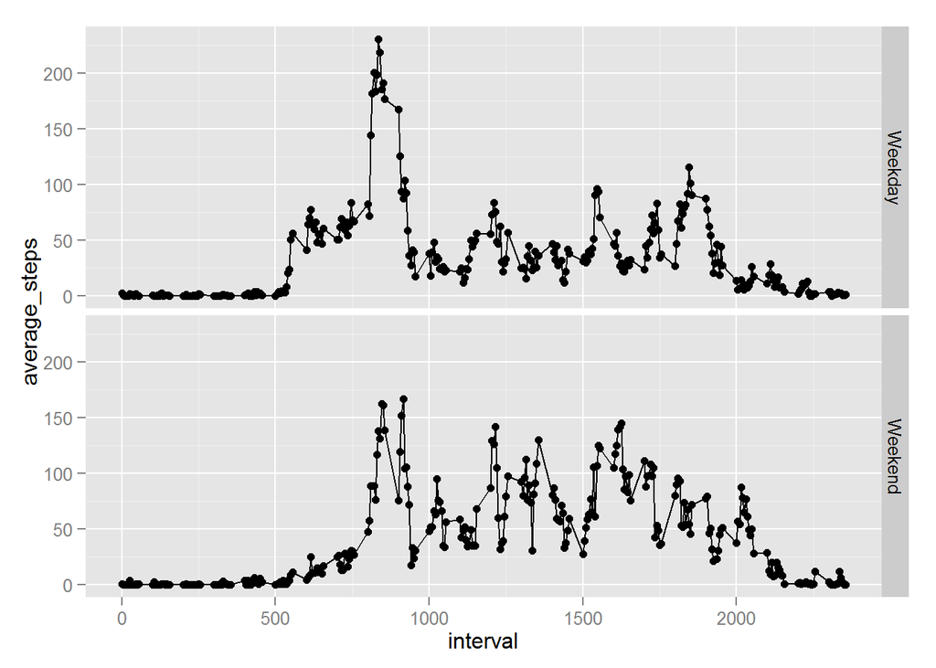

```r
library(ggplot2)
interval_avg2 <- aggregate(data2$steps, by = list(data2$interval, data2$weekend),
                           FUN = mean, na.rm = TRUE)
colnames(interval_avg2) <- c("interval", "Weekday_Weekend", "average_steps")


qplot(interval, average_steps, data=interval_avg2, facets = Weekday_Weekend ~ .) +
    geom_line()
```